# Starting with data

## Learning Objectives

> - load external data (CSV files) in memory using the survey table (`surveys.csv`) as an example
> - understand the concept of a `data.frame`
> - know how to access any element or section of a `data.frame`
> - explore the structure and the content of the data in R
> - understand what factors are and how to manipulate them

# Presentation of the Survey Data

To get the data in a place that R can find it:

- [download the data file](http://emudrak.github.io/2015-01-15-cornell/data/biology/surveys.csv)
- put it in directory `"data"` within your working directory for these exercises
- open it in Excel to see what it looks like

To load our survey data, we need to locate the `surveys.csv` file. We will use `read.csv()` to load into memory (as a `data.frame`) the content of the CSV file.

```r
surveys <- read.csv('data/surveys.csv')
```

**At this point, make sure all participants have the data loaded**

This statement doesn’t produce any output because assignment doesn’t display anything. If we want to check that our data has been loaded, we can print the variable’s value: `surveys`

Wow… that was a lot of output. At least it means the data loaded properly. Let’s check the top (the first 6 lines) of this `data.frame` using the function `head()`:

```r
head(surveys)
```

```
  record_id month day year plot species sex wgt
1         1     7  16 1977    2      NL   M  NA
2         2     7  16 1977    3      NL   M  NA
3         3     7  16 1977    2      DM   F  NA
4         4     7  16 1977    7      DM   M  NA
5         5     7  16 1977    3      DM   M  NA
6         6     7  16 1977    1      PF   M  NA
```

# What are data frames?

`data.frame` is the *de facto* data structure for most tabular data and what we use for statistics and plotting.

A `data.frame` is a collection of vectors of identical lengths. Each vector represents a column, and each vector can be of a different data type (e.g., characters, integers, factors). The `str()` function is useful to inspect the data types of the columns.

A `data.frame` can be created by the functions `read.csv()` or `read.table()`, in other words, when importing spreadsheets from your hard drive (or the web).

R coerces (when possible) to the data type that is the least common denominator and the easiest to coerce to.

# Inspecting data.frame objects

Let’s now check the **str**ucture of this `data.frame` in more details with the function `str()`:

```r
str(surveys)
```

```
'data.frame':   35549 obs. of  8 variables:
 $ record_id: int  1 2 3 4 5 6 7 8 9 10 ...
 $ month    : int  7 7 7 7 7 7 7 7 7 7 ...
 $ day      : int  16 16 16 16 16 16 16 16 16 16 ...
 $ year     : int  1977 1977 1977 1977 1977 1977 1977 1977 1977 1977 ...
 $ plot     : int  2 3 2 7 3 1 2 1 1 6 ...
 $ species  : Factor w/ 49 levels "","AB","AH","AS",..: 17 17 13 13 13 24 23 13 13 24 ...
 $ sex      : Factor w/ 6 levels "","F","M","P",..: 3 3 2 3 3 3 2 3 2 2 ...
 $ wgt      : int  NA NA NA NA NA NA NA NA NA NA ...
```

The first line tells us that we have 35549 observations of 8 variables. We also see the data types for each of the columns in our data.frame.  
You can also see this information in the *Environment tab* if you click the blue arrow button to unfold this information:

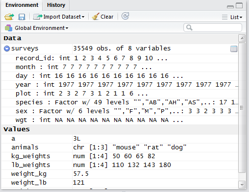

If you want to view the data, click on the grid icon on the right hand side of the line with `surveys` on it. This will open a new tab in the scripts area. You can scroll around, but you cannot edit.

*NOTE:* Values that were blank in the CSV are now listed as `NA`. This is what R uses for missing data (“not available”).

## The $ operator

You’ll notice from the `str()` command that every column name is preceded with the `$` symbol. This is the way to access a single column of the data frame.

For example, you can look at just the species column by typing:

```r
surveys$species
```

Note it doesn’t print a column, but it prints them out with word wrapping. The numbers in the brackets at the left serve as an index.

## Summarizing Functions

We already saw how the functions `head()` and `str()` can be useful to check the content and the structure of a `data.frame`. Here is a non-exhaustive list of functions to get a sense of the content/structure of the data.

- Size:
  - `dim()` - returns a vector with the number of rows in the first element, and the number of columns as the second element (the **dim**ensions of the object)
  - `nrow()` - returns the number of rows
  - `ncol()` - returns the number of columns
- Content:
  - `head()` - shows the first 6 rows
  - `tail()` - shows the last 6 rows
- Names:
  - `names()` - returns the column names (synonym of `colnames()` for `data.frame` objects)
- `rownames()` - returns the row names
- Summary:
- `str()` - structure of the object and information about the class, length and content of each column
- `summary()` - summary statistics for each column

Note: most of these functions are “generic”, they can be used on other types of objects besides `data.frame`.

### Challenge

Can you answer the following questions??

- What is the class of the object `surveys`?
- How many rows and how many columns are in this object?
- How many species have been recorded during these surveys?
- What is the range of years over which this data has been recorded?
- What is the mean weight of animals recorded?

# Indexing and sequences

If we want to extract one or several values from a vector, we must provide one or several indices in square brackets. We will start simply with a vector.

```r
animals <- c("mouse", "rat", "dog", "cat")
animals[2]
```

```
[1] "rat"
```

This will print rat, the second value in the vector `animals`.

R indices start at 1. Programming languages like Fortran, MATLAB, and R start counting at 1, because that’s what human beings typically do.

`:` is a special function that creates numeric vectors of integer in increasing or decreasing order, test `1:10` and `10:1` for instance.

```r
animals[c(3, 2)]
```

```
[1] "dog" "rat"
```

```r
animals[2:4]
```

```
[1] "rat" "dog" "cat"
```

```r
more_animals <- animals[c(1:3, 2:4)]
more_animals
```

```
[1] "mouse" "rat"   "dog"   "rat"   "dog"   "cat"
```

Show everything except a certain index by using the minus sign

```r
animals[-1]
```

```
[1] "rat" "dog" "cat"
```

```r
animals[c(-2,-4)]
```

```
[1] "mouse" "dog"
```

Indexing like this will also work in data frames, but they have two dimensions: rows and columns. If we want to extract some specific data from it, we need to specify the index values for both dimensions. You can think of these as “coordinates”. The syntax for this operation uses brackets, but separates it by a comma: `[ row conditions , column conditions]`. Row numbers come first, followed by column numbers.

*If you have not already downloaded the [surveys](http://emudrak.github.io/2015-01-15-cornell/data/biology/surveys.csv) data and put it in directory `"data"` within your working directory, please do so now.*

```r
surveys[1, 1]   # first element in the first column of the data frame
surveys[1, 6]   # first element in the 6th column
surveys[1:3, 7] # first three elements in the 7th column
surveys[1:3, 4:7] # first three elements in the 4th through 7th columns
surveys[3, ]    # the 3rd element for all columns
surveys[, 8]    # the entire 8th column
```

Failure to specify anything before or after the comma results in the return of the entire row or column.

## Factors

From the str() command, you can see that the columns `species` and `sex` are of a special class called `factor`. They are very useful but not necessarily intuitive, and therefore require some attention.

Factors are used to represent categorical data. Factors can be ordered or unordered and are an important class for statistical analysis and for plotting.

Factors are stored as integers, and have labels associated with these unique integers. This is similar to the way stats programs like JMP or SPSS code the data. While factors look (and often behave) like character vectors, they are actually integers under the hood, and you need to be careful when treating them like strings.

Once created, factors can only contain a pre-defined set values, known as *levels*. By default, R always sorts *levels* in alphabetical order. For instance, if you have a factor with 2 levels:

```r
sex <- factor(c("male", "female", "female", "male"))
sex
```

```
[1] male   female female male
Levels: female male
```

R will assign `1` to the level `"female"` and `2` to the level `"male"` (because `f` comes before `m` in the alphabet, even though the first element in this vector is `"male"`). You can check the names of the levels by using the function `levels()`, and check the number of levels using `nlevels()`:

```r
levels(sex)
```

```
[1] "female" "male"
```

```r
nlevels(sex)
```

```
[1] 2
```

Sometimes, the order of the factors does not matter, other times you might want to specify the order because it is meaningful (e.g., “low”, “medium”, “high”) or it is required by particular type of analysis. Additionally, specifying the order of the levels allows you to compare levels:

```r
food <- factor(c("low", "high", "medium", "high", "low", "medium", "high"))
levels(food)
```

```
[1] "high"   "low"    "medium"
```

```r
food <- factor(food, levels=c("low", "medium", "high"))
levels(food)
```

```
[1] "low"    "medium" "high"
```

In R’s memory, these factors are represented by numbers (1, 2, 3). They are better than using simple integer labels because factors are self describing: `"low"`, `"medium"`, and `"high"`" is more descriptive than `1`, `2`, `3`. Which is low? You wouldn’t be able to tell with just integer data. Factors have this information built in. It is particularly helpful when there are many levels (like the species in our example data set).

## Converting to factors

Look at the data frame structure again:

```r
str(surveys)
```

```
'data.frame':   35549 obs. of  8 variables:
 $ record_id: int  1 2 3 4 5 6 7 8 9 10 ...
 $ month    : int  7 7 7 7 7 7 7 7 7 7 ...
 $ day      : int  16 16 16 16 16 16 16 16 16 16 ...
 $ year     : int  1977 1977 1977 1977 1977 1977 1977 1977 1977 1977 ...
 $ plot     : int  2 3 2 7 3 1 2 1 1 6 ...
 $ species  : Factor w/ 49 levels "","AB","AH","AS",..: 17 17 13 13 13 24 23 13 13 24 ...
 $ sex      : Factor w/ 6 levels "","F","M","P",..: 3 3 2 3 3 3 2 3 2 2 ...
 $ wgt      : int  NA NA NA NA NA NA NA NA NA NA ...
```

The type for “plot” is integer. But the plots could have been labeled with a lettering scheme rather than numbers. There is no concept that plot 4 + plot 2 = plot 6, but right now R thinks that is just fine. So we should really make it a factor.

You can convert this variable to a factor with the `as.factor()` command.

```r
surveys$plot <- as.factor(surveys$plot)
```

Look at the structure of `surveys`. Now, plot is a factor with 24 levels. To us, that line of code changed the data type from `int` to `Factor.

What actually happened was that R evaluated the code on the right of the `<-` (in this case, creating factors of the integers in the plot column), and assigned that value to the object on the left of the `<-`, whcih already existed, so it overwrote the values. That is ok in this case.